# Quarter Back Analysis

```r
library(knitr)
library(devtools)
library(dplyr)
library(ggplot2)
library(gridExtra)
```

Set the working directory to the subdirectory Fantasy Football Directory.

```r
#setwd("~/Desktop/FantasyFootball/notbooks")
```

Open the Quarter Back Data

```r
df_qb <- read.csv("../processed_data/player_data/QB/QB.csv")
head(df_qb)
```

|  | X | Rk | Player | Pos | Week | Team | Opp | Comp | Att | Pct | Yds | Yds.Att | TD | Int | QB.Rating | Att_x | Yds_x | Yds.Att_x | TD_x | Fantasy.Points | year | week | regular.season |
| --- | --- | --- | --- | --- | --- | --- | --- | --- | --- | --- | --- | --- | --- | --- | --- | --- | --- | --- | --- | --- | --- | --- | --- |
| 1 | 1 | 1 | Tom Brady | QB | 1 | NE | MIA | 32 | 48 | 67 | 517 | 11 | 4 | 1 | 122 | 1 | 3 | 3 | 0 | 34.98 | 2011 | 1 | 1 |
| 2 | 2 | 2 | Chad Henne | QB | 1 | MIA | NE | 30 | 49 | 61 | 416 | 9 | 2 | 1 | 94 | 7 | 59 | 8 | 1 | 34.54 | 2011 | 1 | 1 |
| 3 | 3 | 3 | Cam Newton | QB | 1 | CAR | ARI | 24 | 37 | 65 | 422 | 11 | 2 | 1 | 110 | 8 | 18 | 2 | 1 | 30.68 | 2011 | 1 | 1 |
| 4 | 4 | 4 | Drew Brees | QB | 1 | NO | GB | 32 | 49 | 65 | 419 | 9 | 3 | 0 | 113 | 1 | 3 | 3 | 0 | 29.06 | 2011 | 1 | 1 |
| 5 | 5 | 5 | Ryan Fitzpatrick | QB | 1 | BUF | KC | 17 | 25 | 68 | 208 | 8 | 4 | 0 | 133 | 3 | 3 | 1 | 0 | 24.62 | 2011 | 1 | 1 |
| 6 | 6 | 6 | Aaron Rodgers | QB | 1 | GB | NO | 27 | 35 | 77 | 312 | 9 | 3 | 0 | 132 | 4 | 1 | 0 | 0 | 24.58 | 2011 | 1 | 1 |

Get rid of columns I won’t need.

```r
df_qb <-  df_qb %>% select(-Att_x, -Yds_x, -Yds.Att_x, -TD_x)
```

Join Table with schedule table to get next week’s oponent.

```r
df_schedules <- read.csv("../processed_data/schedules.csv")
df_qb <- df_qb %>%  #Add next week's opponent
      left_join(
            df_schedules %>%
                  mutate(previous.week = Week - 1)  %>% #Store the previous week number
                  select(team, year, previous.week, Opponent) %>% # keep only the columns I'll want to join in
                  rename(Next.Opp = Opponent) %>% # rename the next week's opponent column
                  group_by(team, year, previous.week) %>%
                  summarise(Next.Opp = first(Next.Opp)),
            by = c("Team" = "team", "year" = "year", "week" = "previous.week")
      )
```

```
Column `Team`/`team` joining factors with different levels, coercing to character vector
```

Store a series of shift statistics: - Next week’s fantasy points earned (this will be the response variable in the analysis to follow) - Previous week’s attempts - Previous week’s completions - Previous week’s yards - Previous week’s TDs

```r
df_qb <- df_qb %>%
      group_by(Player, year) %>% # group by player and year to ensure stats stay within the current season
      mutate(
            Next.Fantasy.Points = lead(n = 1, Fantasy.Points), #Add the next week's points
            Previous.Att = lag(n = 1, Att), #Add previous week's attempts
            Previous.Comp = lag(n = 1, Comp), #Add previous week's completions
            Previous.Yds = lag(n = 1, Yds), # Previous week's yards
            Previous.TD = lag(n = 1, TD)

            ) %>%
      arrange(Player,year,week) # Sort table to see effect of windowing
```

#### Lets do some basic feature extraction

First, I’ll add the average fanatasy points, attempts, yards, Yards/Attempt, TD and Interceptions from previous year

```r
# Add the average fantasy points in that season.
df_qb <- df_qb %>%
      group_by(Player, year) %>%
      mutate(Avg.Fantasy.Points = mean(Fantasy.Points), # average fantasy points for that year
             Avg.Att = mean(Att), # Average targets for that year
             Avg.Yds = mean(Yds), # Average yards for that year
             Avg.Yds.Att = mean(Yds.Att), #Average yards/attempt for that year
             Avg.TD = mean(TD), #Average TD's per game for that year
             Avg.Int = mean(Int) #Average number of interceptions per game for that year
      )
# Add columns for these averages from the previous season.
df_qb <-  df_qb %>%
      left_join(
            df_qb %>%
                  mutate(next.year = year +1) %>% # Add column for next year
                  group_by(Player, year) %>%
                  mutate(
                              Previous.Avg.Fantasy.Points = first(Avg.Fantasy.Points), #Add average fantasy points
                              Previous.Avg.Att = first(Avg.Att), # Add average attempts/game
                              Previous.Avg.Yds = first(Avg.Yds), # Add average yards/game
                              Previous.Avg.Yds.Att = first(Avg.Yds.Att), #Add average yards/attempt/game
                              Previous.Avg.TD = first(Avg.TD), #Add average TDs/game
                              Previous.Avg.Int = first(Avg.Int) #Add average interceptions per game
                        ) %>%
                  filter(row_number() == 1) %>%  #Only keep one row per player/year group to avoid duplication upon join
                  select(Player, next.year, Previous.Avg.Fantasy.Points, Previous.Avg.Att, Previous.Avg.Yds, Previous.Avg.Yds.Att, Previous.Avg.TD, Previous.Avg.Int)
                  ,
            by = c("Player" = "Player", "year" = "next.year")
            ) %>%
            ungroup()
```

```r
df_qb <- df_qb %>%
      group_by(Player, year) %>%  #Look at players one season at a time
      arrange(week) %>%
      mutate(
            Cum.Avg.Fantasy.Points = cummean(Fantasy.Points), #cumualtive average number of fantasy points per game
            Cum.Avg.Att = cummean(Att), #cumulative average number of attempts per game
            Cum.Avg.Yds = cummean(Yds), #cumulative average number of yards per game
            Cum.Avg.Yds.Att = cummean(Yds.Att), #cumulative average number of yards/attempt per game
            Cum.Avg.TD = cummean(TD), #cumalative average number of TDs
            Cum.Avg.Int = cummean(Int)
      ) %>%
      ungroup()
```

Now, see if the player has increased in performance from previous week to current week. This may suggest that player is on short term “hot streak.”

```r
df_qb <- df_qb %>%
      mutate(
            Att.Increase = Att - Previous.Att, #See the increase/decrease in targets from previous week
            Yds.Increase = Yds - Previous.Yds,
            Comp.Increase = Comp - Previous.Comp
      )
```

Now, I’d like to add some features that show how the opposing team does against this player. First, I’ll add the average number of fantasy points let up by the opponent to players of the position in quetion in the previous two seasons.

```r
df_qb <- df_qb %>%
      left_join( #add the average points let up by opponent in previous year
            df_qb %>%
                  group_by(Opp, year) %>%
                  summarise(Avg.Points.Allowed.Last.Year = mean(Fantasy.Points)) %>% #average fantasy points allowed by opponent last year
                  ungroup() %>%
                  mutate(next.year = year + 1) #will be used to join with year column to get last year's avg points allowed
      ,
      by = c("Next.Opp" = "Opp", "year" = "next.year")
      ) %>%
      left_join( #add the average points let up by next week's opponent two years ago
            df_qb %>%
                  group_by(Opp, year) %>%
                  summarise(Avg.Points.Allowed.Last.Last.Year = mean(Fantasy.Points)) %>% #average fantasy points allowed by opponent last year
                  ungroup() %>%
                  mutate(next.next.year = year + 2) #will be used to join with year column to get last year's avg points allowed
      ,
      by = c("Next.Opp" = "Opp", "year" = "next.next.year")
      )
```

```
Column `Next.Opp`/`Opp` joining factors with different levels, coercing to character vectorColumn `Next.Opp`/`Opp` joining character vector and factor, coercing into character vector
```

```r
# When Next.Opp is NA, it means that there is no team to be played next week because the player will be on a bye week.
# This will cause the columns 'Avg.Points.Allowed.Last.Year' and 'Avg.Points.Allowed.Last.Last.Year' to be NA as well.
# Since I want to use these columns for my model, I'll fill the with something reasonable - the average amount of points allowed.
df_qb[is.na(df_qb$Avg.Points.Allowed.Last.Year), "Avg.Points.Allowed.Last.Year"] <- mean(df_qb$Avg.Points.Allowed.Last.Year, na.rm = TRUE)
df_qb[is.na(df_qb$Avg.Points.Allowed.Last.Last.Year), "Avg.Points.Allowed.Last.Last.Year"] <- mean(df_qb$Avg.Points.Allowed.Last.Last.Year, na.rm = TRUE)
```

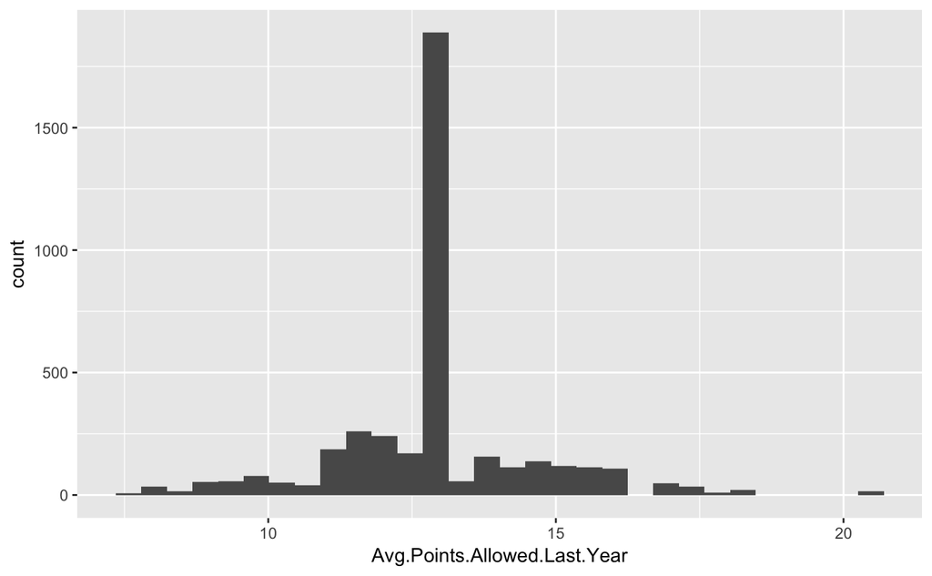

```r
df_qb %>% ggplot(aes(x = Avg.Points.Allowed.Last.Year)) + geom_histogram()
```

I use many lagged statistics from previous years. This has two problems. First, the state of Football has changed in recent times - offenses are more productive than they used to be. It may not make sense to a model to data from too far back. Second, many of the features I extract rely on looking back to performances of previous years. This results in NA’s if there are no years to look back to in the datast.

As such, I will remove the two earliest years in the dataset - 2011 and 2012.

```r
df_qb <- df_qb %>% filter(year > 2012)
```

To determine if a performance is “uncharactaristic”, I’ll use the boxplot (Tukey) outlier method.

```r
test <-
df_qb %>% #Join to get the upper and lower Tukey thresholds for a player's fantasy points, based on data since 2014.
      left_join(
                df_qb %>%
                      group_by(Player) %>% #finding average for each player
                      summarize(
                            Q25.Fantasy.Points = quantile(Fantasy.Points, probs = .25), #25th quantile of fantasy points earned in games since 2014
                            Q75.Fantasy.Points = quantile(Fantasy.Points, probs = .75) #75th quantile of fantasy points earned in games since 2014
                      ) %>%
                      mutate( IQR.Fantasy.Points = Q75.Fantasy.Points - Q25.Fantasy.Points) %>% #Get the IQR of fantasy points earned since 2014
                      mutate(
                            Lower.Limit.Fantasy.Points = Q25.Fantasy.Points - 3*IQR.Fantasy.Points,
                            Upper.Limit.Fantasy.Points = Q75.Fantasy.Points + 3*IQR.Fantasy.Points #calculate lower and upper tukey limits
                      ) %>%
                      select(Player, Lower.Limit.Fantasy.Points, Upper.Limit.Fantasy.Points) #keep only columns I want to bring over in join
                ,
                by = "Player"
      ) %>%
      filter( Fantasy.Points >= Lower.Limit.Fantasy.Points & Fantasy.Points <= Upper.Limit.Fantasy.Points)
```

Fill NA values in test

```r
test[is.na(test)] <- 0
```

```r
str(test)
```

```
Classes ‘tbl_df’, ‘tbl’ and 'data.frame':   2646 obs. of  53 variables:
 $ X                                : int  1361 2033 2685 3362 1370 2032 2684 3358 1360 2008 ...
 $ Rk                               : int  6 28 5 7 15 27 4 3 5 3 ...
 $ Player                           : Factor w/ 142 levels "Aaron Rodgers",..: 1 1 1 1 4 4 4 4 6 6 ...
 $ Pos                              : Factor w/ 1 level "QB": 1 1 1 1 1 1 1 1 1 1 ...
 $ Week                             : int  1 1 1 1 1 1 1 1 1 1 ...
 $ Team                             : chr  "GB" "GB" "GB" "GB" ...
 $ Opp                              : Factor w/ 32 levels "ARI","ATL","BAL",..: 29 28 6 15 15 31 13 17 25 10 ...
 $ Comp                             : int  21 23 18 20 21 19 22 34 18 35 ...
 $ Att                              : int  37 33 23 34 34 35 33 48 23 53 ...
 $ Pct                              : int  57 70 78 59 62 54 67 71 78 66 ...
 $ Yds                              : int  333 189 189 199 173 202 243 363 178 370 ...
 $ Yds.Att                          : int  9 6 8 6 5 6 7 8 8 7 ...
 $ TD                               : int  3 1 3 2 2 1 3 2 2 2 ...
 $ Int                              : int  1 1 0 0 0 3 0 1 0 2 ...
```

[output cut: 39 more lines]

### Create a dummy model

```r
model <- lm(data = test, Next.Fantasy.Points ~ Fantasy.Points  + Previous.Avg.Yds + Previous.Avg.Int +   Cum.Avg.Att + Cum.Avg.TD +  Cum.Avg.Yds +  Avg.Points.Allowed.Last.Year ,  na.action = na.exclude )
summary(model)
```

```
Call:
lm(formula = Next.Fantasy.Points ~ Fantasy.Points + Previous.Avg.Yds +
    Previous.Avg.Int + Cum.Avg.Att + Cum.Avg.TD + Cum.Avg.Yds +
    Avg.Points.Allowed.Last.Year, data = test, na.action = na.exclude)

Residuals:
    Min      1Q  Median      3Q     Max
-21.102  -4.904  -0.851   5.196  35.465

Coefficients:
                              Estimate Std. Error t value Pr(>|t|)
(Intercept)                  -1.343248   1.209645  -1.110 0.266907
Fantasy.Points                0.086804   0.024738   3.509 0.000457 ***
Previous.Avg.Yds              0.014809   0.002636   5.617 2.14e-08 ***
Previous.Avg.Int             -1.491287   0.552712  -2.698 0.007017 **
Cum.Avg.Att                   0.117873   0.042358   2.783 0.005427 **
Cum.Avg.TD                    1.200132   0.371245   3.233 0.001241 **
Cum.Avg.Yds                   0.013790   0.006689   2.062 0.039329 *
Avg.Points.Allowed.Last.Year  0.228271   0.087525   2.608 0.009157 **
---
Signif. codes:  0 ‘***’ 0.001 ‘**’ 0.01 ‘*’ 0.05 ‘.’ 0.1 ‘ ’ 1

Residual standard error: 8.054 on 2638 degrees of freedom
Multiple R-squared:  0.2775,    Adjusted R-squared:  0.2756
F-statistic: 144.7 on 7 and 2638 DF,  p-value: < 2.2e-16
```

Add predicitions

```r
test$Predictions = predict(model)
test$Residuals = resid(model)
```

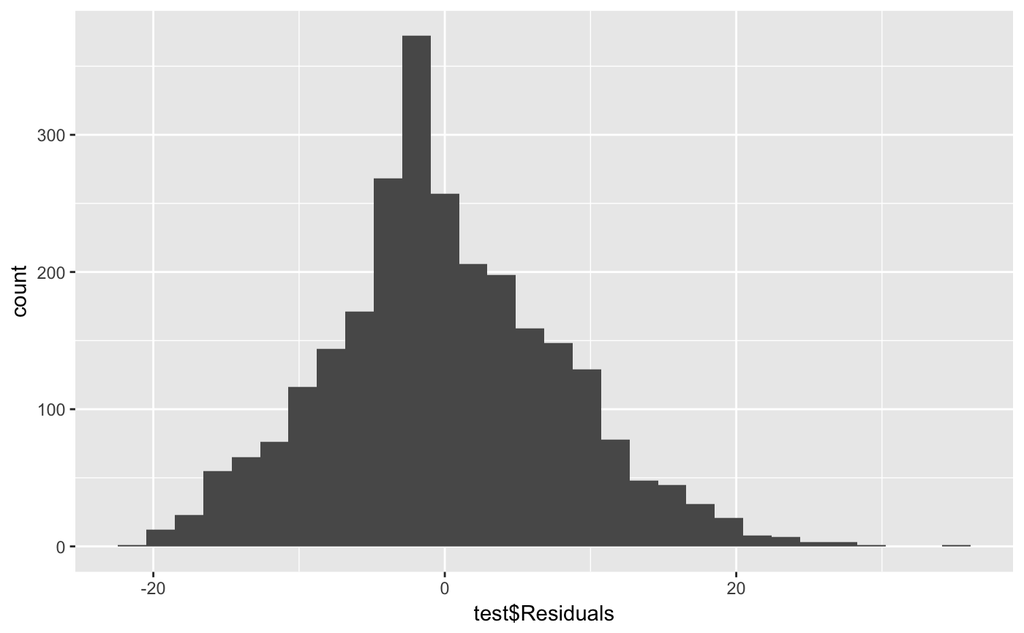

```r
qplot(test$Residuals)
```

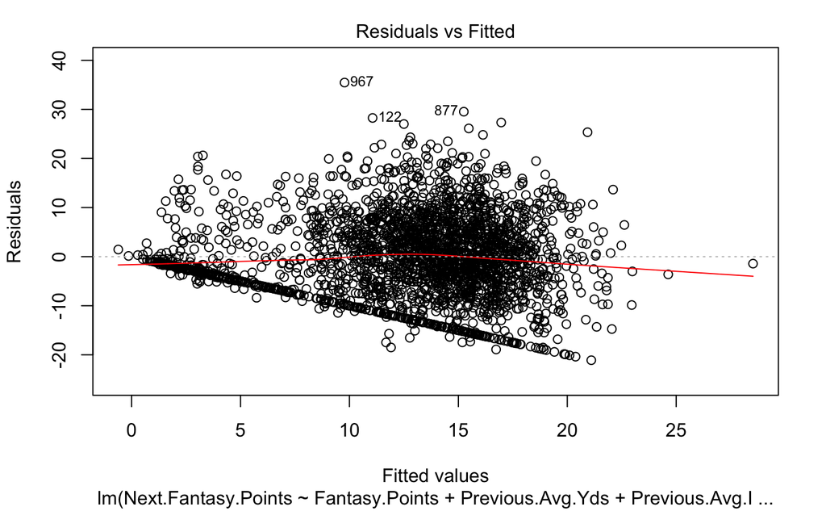

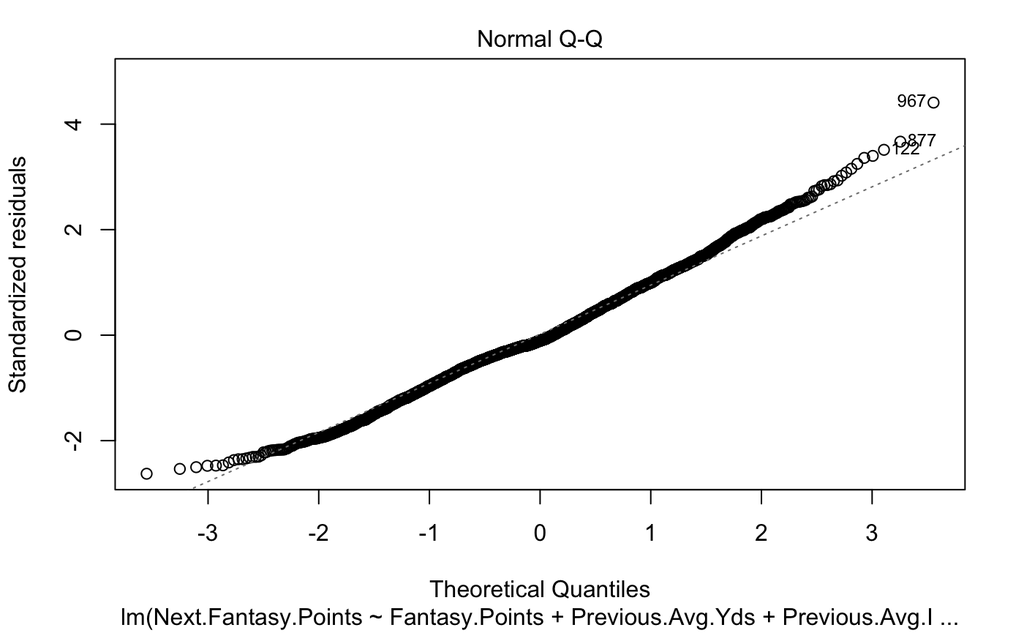

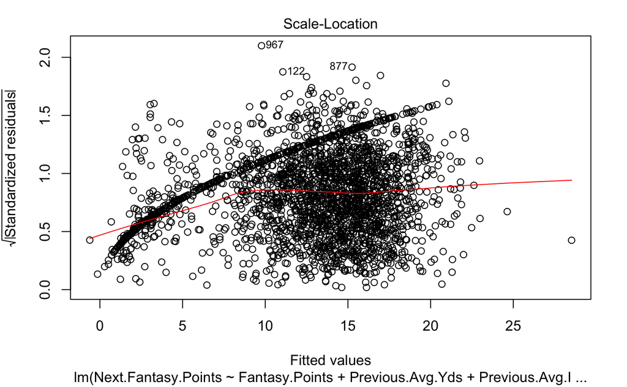

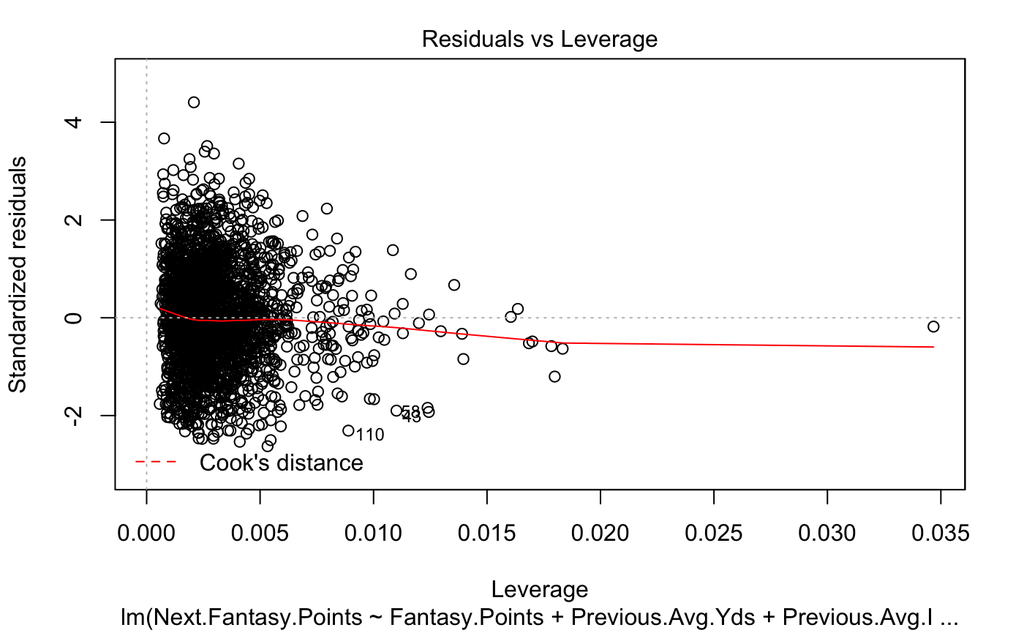

```r
plot(model)
```

### Prioritize players for lineup

```r
      predictions <- test %>%
            mutate(max_year = max(year)) %>%
            filter(year == max_year) %>% #keep only most recent year's predictions
            group_by(Player) %>% #group by player to get the most recent week the player has played
            mutate(max_week = max(week)) %>%
            filter(week == max_week) %>% #Only keep each player's last week predictions
            select (Player, Team, Pos, year, week, Previous.Avg.Fantasy.Points, Predictions) %>% #Information I'd like to see when chosing lineup
            arrange(desc(Predictions)) %>%
            ungroup() %>%
            top_n(20)
      predictions
```

| Player | Team | Pos | year | week | Previous.Avg.Fantasy.Points | Predictions |
| --- | --- | --- | --- | --- | --- | --- |
| Drew Brees | NO | QB | 2016 | 18 | 20.04375 | 20.46677 |
| Tom Brady | NE | QB | 2016 | 17 | 21.84235 | 18.74761 |
| Aaron Rodgers | GB | QB | 2016 | 18 | 19.07647 | 17.62220 |
| Matt Ryan | ATL | QB | 2016 | 18 | 14.73882 | 17.47470 |
| Carson Palmer | ARI | QB | 2016 | 18 | 19.70118 | 17.27040 |
| Ben Roethlisberger | PIT | QB | 2016 | 18 | 18.93538 | 17.06762 |
| Andrew Luck | IND | QB | 2016 | 18 | 18.57000 | 16.97837 |
| Matthew Stafford | DET | QB | 2016 | 18 | 17.85412 | 16.55966 |
| Philip Rivers | LAC | QB | 2016 | 18 | 17.90588 | 16.49321 |
| Derek Carr | OAK | QB | 2016 | 18 | 16.14824 | 16.16693 |

[output cut: 10 more lines]

```r
write.csv(predictions, "../predictions/week-1/QB.csv")
```